# AdaBoosting and XGBoosting

### Problem Statement :-

- Perform AdaBoost and Extreme Gradient Boosting for the WBCD dataset

### Data Understanding

```r
library(readr)
wbcd <- read_csv("/Users/thanush/Desktop/Digi 360/Module 20/Datasets-9/wbcd.csv")
head(wbcd)
```

```
## # A tibble: 6 x 32
##       id diagnosis radius_mean texture_mean perimeter_mean area_mean
##    <dbl> <chr>           <dbl>        <dbl>          <dbl>     <dbl>
## 1 8.71e7 B                12.3         12.4           78.8      464.
## 2 8.91e6 B                10.6         19.0           69.3      346.
## 3 9.06e5 B                11.0         16.8           70.9      373.
## 4 8.69e5 B                11.3         13.4           73        385.
## 5 9.01e6 B                15.2         13.2           97.6      712.
## 6 9.07e5 B                11.6         19.0           74.2      410.
## # … with 26 more variables: smoothness_mean <dbl>, compactness_mean <dbl>,
## #   concavity_mean <dbl>, points_mean <dbl>, symmetry_mean <dbl>,
## #   dimension_mean <dbl>, radius_se <dbl>, texture_se <dbl>,
## #   perimeter_se <dbl>, area_se <dbl>, smoothness_se <dbl>,
## #   compactness_se <dbl>, concavity_se <dbl>, points_se <dbl>,
## #   symmetry_se <dbl>, dimension_se <dbl>, radius_worst <dbl>,
## #   texture_worst <dbl>, perimeter_worst <dbl>, area_worst <dbl>,
## #   smoothness_worst <dbl>, compactness_worst <dbl>, concavity_worst <dbl>,
## #   points_worst <dbl>, symmetry_worst <dbl>, dimension_worst <dbl>
```

```r
wbcd <- wbcd[-c(1)]
head(wbcd)
```

```
## # A tibble: 6 x 31
##   diagnosis radius_mean texture_mean perimeter_mean area_mean smoothness_mean
##   <chr>           <dbl>        <dbl>          <dbl>     <dbl>           <dbl>
## 1 B                12.3         12.4           78.8      464.          0.103
## 2 B                10.6         19.0           69.3      346.          0.0969
## 3 B                11.0         16.8           70.9      373.          0.108
## 4 B                11.3         13.4           73        385.          0.116
## 5 B                15.2         13.2           97.6      712.          0.0796
## 6 B                11.6         19.0           74.2      410.          0.0855
## # … with 25 more variables: compactness_mean <dbl>, concavity_mean <dbl>,
## #   points_mean <dbl>, symmetry_mean <dbl>, dimension_mean <dbl>,
## #   radius_se <dbl>, texture_se <dbl>, perimeter_se <dbl>, area_se <dbl>,
## #   smoothness_se <dbl>, compactness_se <dbl>, concavity_se <dbl>,
## #   points_se <dbl>, symmetry_se <dbl>, dimension_se <dbl>, radius_worst <dbl>,
## #   texture_worst <dbl>, perimeter_worst <dbl>, area_worst <dbl>,
## #   smoothness_worst <dbl>, compactness_worst <dbl>, concavity_worst <dbl>,
## #   points_worst <dbl>, symmetry_worst <dbl>, dimension_worst <dbl>
```

```r
#converting features into factor
wbcd$diagnosis <- as.factor(wbcd$diagnosis)
str(wbcd)
```

```
## tibble [569 × 31] (S3: tbl_df/tbl/data.frame)
##  $ diagnosis        : Factor w/ 2 levels "B","M": 1 1 1 1 1 1 1 2 1 1 ...
##  $ radius_mean      : num [1:569] 12.3 10.6 11 11.3 15.2 ...
##  $ texture_mean     : num [1:569] 12.4 18.9 16.8 13.4 13.2 ...
##  $ perimeter_mean   : num [1:569] 78.8 69.3 70.9 73 97.7 ...
##  $ area_mean        : num [1:569] 464 346 373 385 712 ...
##  $ smoothness_mean  : num [1:569] 0.1028 0.0969 0.1077 0.1164 0.0796 ...
##  $ compactness_mean : num [1:569] 0.0698 0.1147 0.078 0.1136 0.0693 ...
##  $ concavity_mean   : num [1:569] 0.0399 0.0639 0.0305 0.0464 0.0339 ...
##  $ points_mean      : num [1:569] 0.037 0.0264 0.0248 0.048 0.0266 ...
##  $ symmetry_mean    : num [1:569] 0.196 0.192 0.171 0.177 0.172 ...
##  $ dimension_mean   : num [1:569] 0.0595 0.0649 0.0634 0.0607 0.0554 ...
##  $ radius_se        : num [1:569] 0.236 0.451 0.197 0.338 0.178 ...
##  $ texture_se       : num [1:569] 0.666 1.197 1.387 1.343 0.412 ...
##  $ perimeter_se     : num [1:569] 1.67 3.43 1.34 1.85 1.34 ...
```

[output cut: 17 more lines]

```r
library(caret)
library(tibble)
set.seed(1000)
index <- createDataPartition(y = wbcd$diagnosis, p = 0.7, list = FALSE)
train <- wbcd[index, ]
test <- wbcd[-index, ]
```

```r
head(train)
```

```
## # A tibble: 6 x 31
##   diagnosis radius_mean texture_mean perimeter_mean area_mean smoothness_mean
##   <fct>           <dbl>        <dbl>          <dbl>     <dbl>           <dbl>
## 1 B                10.6         19.0           69.3      346.          0.0969
## 2 B                11.0         16.8           70.9      373.          0.108
## 3 B                11.3         13.4           73        385.          0.116
## 4 B                15.2         13.2           97.6      712.          0.0796
## 5 B                11.6         19.0           74.2      410.          0.0855
## 6 B                11.5         23.9           74.5      404.          0.0926
## # … with 25 more variables: compactness_mean <dbl>, concavity_mean <dbl>,
## #   points_mean <dbl>, symmetry_mean <dbl>, dimension_mean <dbl>,
## #   radius_se <dbl>, texture_se <dbl>, perimeter_se <dbl>, area_se <dbl>,
## #   smoothness_se <dbl>, compactness_se <dbl>, concavity_se <dbl>,
## #   points_se <dbl>, symmetry_se <dbl>, dimension_se <dbl>, radius_worst <dbl>,
## #   texture_worst <dbl>, perimeter_worst <dbl>, area_worst <dbl>,
## #   smoothness_worst <dbl>, compactness_worst <dbl>, concavity_worst <dbl>,
## #   points_worst <dbl>, symmetry_worst <dbl>, dimension_worst <dbl>
```

### Extreme Gradient Boosting

To use xgboost package, keep these things in mind: - Convert the categorical variables into numeric using one hot encoding - For classification, if the dependent variable belongs to class factor, convert it to numeric

```r
#convert data frame to data table
library(data.table)
library(mlr)
setDT(train)
setDT(test)
```

```r
#using one hot encoding
train_label <- train$diagnosis
test_label <- test$diagnosis
```

```r
train_label
```

```
##   [1] B B B B B B M B B M M B B M B B B B B M B M B B B M M B B B M B M M M M B
##  [38] B M B M B M B B B M M M B M B B B M B B B B B B B M B B B M B M B B B M B
##  [75] B B B B M M B M M M M B B M B B M M M M B B M B M B M M M B M B B B B B B
## [112] M B B B B M M M B M B B M B B M B M M M B M B B M M M B B M B B B B M B M
## [149] M B B B M M B B B B M M B B B B B B B B B M B B B M B B B B B B B B M B M
## [186] B B B M M B B M M B M B B B B B M B M B B B M B M M M M M B B B M M B M M
## [223] B B B M M B M B M B M B B B M B B M B M B B B B B B B B B M B M B B M B B
## [260] B B B B B B B B M M M B M B M B B B M B B M B M B B M B B B B B M B B M M
## [297] B M B B M B M M B B B B B M B B B M B M M B M M B B M B B B B B B M B M B
## [334] M B M B B M M M B B B M M M M M B B B B M M B M B M M M M M M B B B M B B
## [371] B B B B M B B M M B B B B B B M B M B B B B M B B B B M M
## Levels: B M
```

```r
new_train <- model.matrix(~.+0,data = train[,-c("diagnosis"),with=F])
new_test <- model.matrix(~.+0,data = test[,-c("diagnosis"),with=F])
```

```r
#convert factor to numeric
train_label <- as.numeric(train_label)-1
test_label <- as.numeric(test_label)-1
```

```r
train_label
```

```
##   [1] 0 0 0 0 0 0 1 0 0 1 1 0 0 1 0 0 0 0 0 1 0 1 0 0 0 1 1 0 0 0 1 0 1 1 1 1 0
##  [38] 0 1 0 1 0 1 0 0 0 1 1 1 0 1 0 0 0 1 0 0 0 0 0 0 0 1 0 0 0 1 0 1 0 0 0 1 0
##  [75] 0 0 0 0 1 1 0 1 1 1 1 0 0 1 0 0 1 1 1 1 0 0 1 0 1 0 1 1 1 0 1 0 0 0 0 0 0
## [112] 1 0 0 0 0 1 1 1 0 1 0 0 1 0 0 1 0 1 1 1 0 1 0 0 1 1 1 0 0 1 0 0 0 0 1 0 1
## [149] 1 0 0 0 1 1 0 0 0 0 1 1 0 0 0 0 0 0 0 0 0 1 0 0 0 1 0 0 0 0 0 0 0 0 1 0 1
## [186] 0 0 0 1 1 0 0 1 1 0 1 0 0 0 0 0 1 0 1 0 0 0 1 0 1 1 1 1 1 0 0 0 1 1 0 1 1
## [223] 0 0 0 1 1 0 1 0 1 0 1 0 0 0 1 0 0 1 0 1 0 0 0 0 0 0 0 0 0 1 0 1 0 0 1 0 0
## [260] 0 0 0 0 0 0 0 0 1 1 1 0 1 0 1 0 0 0 1 0 0 1 0 1 0 0 1 0 0 0 0 0 1 0 0 1 1
## [297] 0 1 0 0 1 0 1 1 0 0 0 0 0 1 0 0 0 1 0 1 1 0 1 1 0 0 1 0 0 0 0 0 0 1 0 1 0
## [334] 1 0 1 0 0 1 1 1 0 0 0 1 1 1 1 1 0 0 0 0 1 1 0 1 0 1 1 1 1 1 1 0 0 0 1 0 0
## [371] 0 0 0 0 1 0 0 1 1 0 0 0 0 0 0 1 0 1 0 0 0 0 1 0 0 0 0 1 1
```

For xgboost, we’ll use xgb.DMatrix to convert data table into a matrix

```r
library(xgboost)
library(dplyr)
#preparing matrix
dtrain <- xgb.DMatrix(data = new_train,label = train_label)
dtest <- xgb.DMatrix(data = new_test,label=test_label)
```

### Building Model with Default Parameters

```r
#default parameters
params <- list(booster = "gbtree", objective = "binary:logistic", eta=0.3, gamma=0, max_depth=6, min_child_weight=1, subsample=1, colsample_bytree=1)
```

Using the inbuilt xgb.cv function, let’s calculate the best nround for this model.

### Cross Validation

```r
set.seed(1000)
xgbcv <- xgb.cv( params = params, data = dtrain, nrounds = 100, nfold = 5, showsd = T, stratified = T, print_every_n = 10, early_stopping_rounds = 20, maximize = F)
```

[output not shown]

### Training the Model

```r
#first default - model training
xgb1 <- xgb.train (params = params, data = dtrain, nrounds = 71, watchlist = list(val=dtest,train=dtrain), print_every_n = 10, early_stoppin_rounds = 10, maximize = F , eval_metric = "error")
```

[output not shown]

### Model Evolution

```r
#model prediction
xgbpred <- predict (xgb1,dtest)
xgbpred <- ifelse (xgbpred > 0.5,1,0)
```

The objective function binary:logistic returns output probabilities rather than labels. To convert it, we need to manually use a cutoff value. As seen above, I’ve used 0.5 as my cutoff value for predictions. We can calculate our model’s accuracy using confusionMatrix() function from caret package.

```r
#confusion matrix
library(caret)
confusionMatrix(as.factor(xgbpred), as.factor(test_label))
```

```
## Confusion Matrix and Statistics
##
##           Reference
## Prediction   0   1
##          0 104   4
##          1   3  59
##
##                Accuracy : 0.9588
##                  95% CI : (0.917, 0.9833)
##     No Information Rate : 0.6294
##     P-Value [Acc > NIR] : <2e-16
##
##                   Kappa : 0.9114
##
##  Mcnemar's Test P-Value : 1
##
##             Sensitivity : 0.9720
##             Specificity : 0.9365
##          Pos Pred Value : 0.9630
##          Neg Pred Value : 0.9516
##              Prevalence : 0.6294
##          Detection Rate : 0.6118
##    Detection Prevalence : 0.6353
##       Balanced Accuracy : 0.9542
##
##        'Positive' Class : 0
##
```

The accuracy of the model is 96%.

### Feature Importance

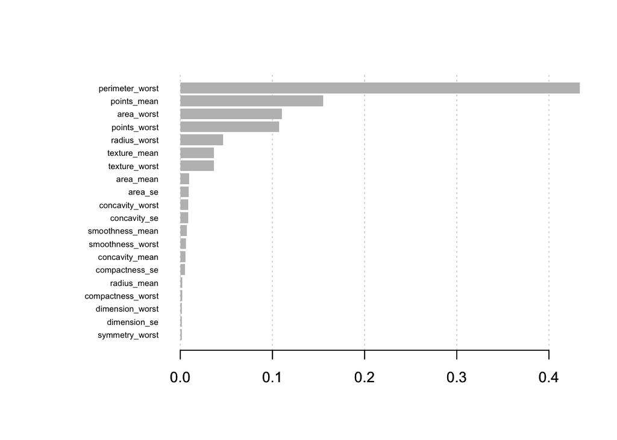

```r
#view variable importance plot
mat <- xgb.importance (feature_names = colnames(new_train),model = xgb1)
xgb.plot.importance (importance_matrix = mat[1:20])
```

### Adaboosting

```r
library(parallel)
library(parallelMap)
library(mlr)
library(dplyr)
library(caret)
library(data.table)
```

```r
# Let's build the model on train data
parallelStartSocket(cpus = detectCores())
```

```
## Starting parallelization in mode=socket with cpus=4.
```

```r
library(adabag)
library(rpart)
set.seed(1000)
model = boosting(diagnosis~., data=train, boos=TRUE, mfinal=10, coeflearn = 'Zhu',control=rpart.control(maxdepth=3))
```

```r
print(names(model))
```

```
## [1] "formula"    "trees"      "weights"    "votes"      "prob"
## [6] "class"      "importance" "terms"      "call"
```

```r
print(model$trees[1])
```

```
## [[1]]
## n= 399
##
## node), split, n, loss, yval, (yprob)
##       * denotes terminal node
##
## 1) root 399 157 B (0.60651629 0.39348371)
##   2) points_worst< 0.14595 254  17 B (0.93307087 0.06692913)
##     4) radius_worst< 17.755 241   5 B (0.97925311 0.02074689) *
##     5) radius_worst>=17.755 13   1 M (0.07692308 0.92307692) *
##   3) points_worst>=0.14595 145   5 M (0.03448276 0.96551724) *
```

### Model Evolution

```r
pred = predict(model, test)
```

```r
print(pred$confusion)
```

```
##                Observed Class
## Predicted Class   B   M
##               B 104   2
##               M   3  61
```

```r
accuracy = (104 + 61)/(104 + 61 + 3 + 2)
accuracy
```

```
## [1] 0.9705882
```

### Cross Validation Model

```r
set.seed(1000)
cvmodel = boosting.cv(diagnosis~., data=train, boos=TRUE, mfinal=10, v=5)
```

```
## i:  1 Sat Jun 20 12:39:00 2020
## i:  2 Sat Jun 20 12:39:04 2020
## i:  3 Sat Jun 20 12:39:08 2020
## i:  4 Sat Jun 20 12:39:11 2020
## i:  5 Sat Jun 20 12:39:15 2020
```

```r
parallelStop()
```

```
## Stopped parallelization. All cleaned up.
```

```r
cvmodel
```

```
## $class
##   [1] "B" "B" "B" "B" "B" "B" "M" "B" "B" "M" "M" "B" "B" "M" "B" "B" "B" "M"
##  [19] "B" "B" "B" "M" "B" "B" "B" "B" "M" "B" "B" "B" "M" "B" "M" "M" "M" "M"
##  [37] "B" "B" "M" "B" "M" "B" "M" "B" "B" "B" "M" "M" "M" "B" "M" "B" "B" "M"
##  [55] "M" "B" "B" "B" "B" "B" "B" "B" "M" "B" "B" "B" "B" "B" "M" "B" "B" "B"
##  [73] "M" "B" "B" "B" "B" "B" "M" "M" "B" "M" "M" "M" "M" "B" "B" "M" "B" "B"
##  [91] "M" "M" "B" "M" "B" "B" "M" "B" "M" "B" "M" "M" "M" "B" "M" "B" "B" "B"
## [109] "B" "B" "B" "B" "B" "B" "B" "B" "M" "M" "M" "B" "M" "B" "B" "M" "B" "B"
## [127] "M" "B" "M" "M" "M" "B" "M" "B" "B" "M" "M" "M" "B" "B" "B" "B" "B" "B"
## [145] "B" "M" "B" "M" "M" "B" "B" "B" "M" "M" "B" "B" "B" "B" "M" "M" "B" "B"
## [163] "B" "B" "B" "B" "B" "B" "B" "B" "B" "B" "M" "M" "B" "B" "B" "M" "B" "B"
## [181] "B" "B" "M" "B" "M" "B" "B" "B" "M" "M" "B" "B" "M" "M" "B" "M" "B" "B"
## [199] "B" "B" "B" "M" "B" "M" "B" "B" "B" "M" "B" "M" "M" "M" "M" "M" "B" "B"
## [217] "B" "M" "M" "B" "M" "M" "B" "B" "B" "M" "M" "B" "M" "B" "M" "B" "M" "M"
## [235] "B" "B" "M" "M" "M" "M" "B" "M" "B" "B" "B" "B" "B" "B" "B" "B" "B" "M"
```

[output cut: 18 more lines]

```r
accuracy = (242 + 137)/(242 + 137 + 8 + 12)
accuracy
```

```
## [1] 0.9498747
```

### Conclusion:-

- With Adaboosting the accuracy is 97%.
- With Adaboosting cross validation the accuracy is 95%
- With XGBoosting the accuracy is 96%.
- The most important features are `perimeter_worst`, `points_mean`, `area_worst`, `points_worst` and `radius_worst`